# Two-sample T test, Wilcoxon Rank-Sum Test, Resampling, Difference in Proportions

Brendan Mapes

9/23/2021

### Using R’s “Crabs” data

```r
crab <- crabs
crab_O <- subset(crab, sp =="O")
crab_B <- subset(crab, sp =="B")

#two sample t-test (Parametric)
t.test(crab_O$CL, crab_B$CL, alternative = "two.sided", var.equal = FALSE)
```

```
##
##  Welch Two Sample t-test
##
## data:  crab_O$CL and crab_B$CL
## t = 4.2372, df = 197.92, p-value = 3.468e-05
## alternative hypothesis: true difference in means is not equal to 0
## 95 percent confidence interval:
##  2.189139 6.000861
## sample estimates:
## mean of x mean of y
##    34.153    30.058
```

```r
#Wilcoxon rank-sum test (Non-parametric)
wilcox.test(crab_O$CL, crab_B$CL, alternative = "two.sided")
```

```
##
##  Wilcoxon rank sum test with continuity correction
##
## data:  crab_O$CL and crab_B$CL
## W = 6621.5, p-value = 7.469e-05
## alternative hypothesis: true location shift is not equal to 0
```

```r
#resampling
mean(sample(crab_O$CL, size = 100, replace = T))
```

```
## [1] 34.489
```

```r
mean(sample(crab_B$CL, size = 100, replace = T))
```

```
## [1] 29.81
```

```r
#resampled t-test
resample_O <- sample(crab_O$CL, size = 100, replace = T)
resample_B <- sample(crab_B$CL, size = 100, replace = T)
t.test(resample_O, resample_B, alternative = "two.sided", var.equal = FALSE)
```

```
##
##  Welch Two Sample t-test
##
## data:  resample_O and resample_B
## t = 2.3941, df = 197.82, p-value = 0.0176
## alternative hypothesis: true difference in means is not equal to 0
## 95 percent confidence interval:
##  0.4093332 4.2346668
## sample estimates:
## mean of x mean of y
##    32.906    30.584
```

The majority of these assumptions are valid in this case. However, the sample is not large enough to create what appears to be a normal distribution, especially in the case of the blue crabs, so a larger sample would be ideal. More information on the sampling method would also be necessary, to ensure that the sample is representative of the population of crabs as a whole. F-test below reveals that variances of the samples are not exactly equal, however very close 0.9602902. A larger sample would likely help this assumption as well. With large samples, as long as data is approximately normal, and variances are approximately equal as they are here, this test’s results are trustworthy. The other assumptions do hold true in this test.

The wilcoxon rank sum test does not assume the that the data analyzed has a normal distribution, so it may also be a solution to test these means if the data truly don’t follow a normal distribution. The other assumptions of the wilcoxon rank sum test match those of the two sample t-test, and two sample t-test on the resampled data.

EDA to check some of the assumptions named here is included below.

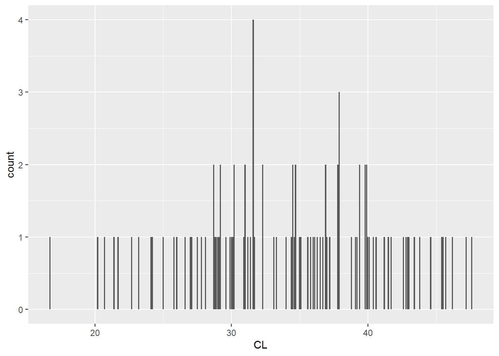

```r
#check distributions
dist <- ggplot(data = crab_O) + geom_bar(mapping = aes(x=CL))
dist2 <- ggplot(data = crab_B) + geom_bar(mapping = aes(x=CL))
dist
```

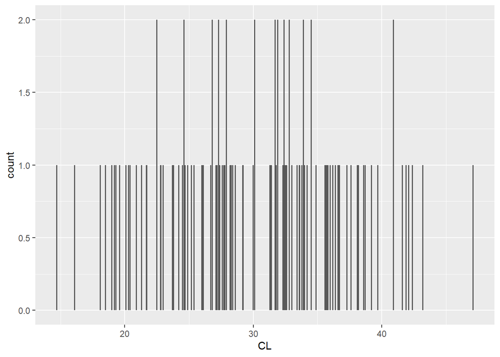

```r
dist2
```

```r
#check variances
var.test(crab_O$CL, crab_B$CL, alternative = "two.sided")
```

```
##
##  F test to compare two variances
##
## data:  crab_O$CL and crab_B$CL
## F = 0.96029, num df = 99, denom df = 99, p-value = 0.8406
## alternative hypothesis: true ratio of variances is not equal to 1
## 95 percent confidence interval:
##  0.6461232 1.4272157
## sample estimates:
## ratio of variances
##          0.9602902
```

Using R’s “ToothGrowth” data

*If “len” is above 20, it is classified as “HIGH”; and ”LOW”, otherwise. Determining whether there is a significant difference in the proportions of the two groupsclassified as “HIGH” using a test of proportions with a 95% confidence interval.*

```r
tooth <- ToothGrowth

#classifying as directed
tooth <- tooth %>% mutate(classify = ifelse(len > 20, "HIGH", "LOW"))
tooth_1 <- tooth %>% select(!dose)
tooth_VC <- subset(tooth_1, supp =="VC")
tooth_OJ <- subset(tooth_1, supp =="OJ")

VC_high <- subset(tooth_VC, classify =="HIGH")
OJ_high <- subset(tooth_OJ, classify =="HIGH")

#proportion test based off number of those classified as high and total number of samples
proportion_test <- prop.test(x = c(18, 10), n = c(30, 30))
proportion_test
```

```
##
##  2-sample test for equality of proportions with continuity correction
##
## data:  c(18, 10) out of c(30, 30)
## X-squared = 3.2812, df = 1, p-value = 0.07008
## alternative hypothesis: two.sided
## 95 percent confidence interval:
##  -0.009950289  0.543283623
## sample estimates:
##    prop 1    prop 2
## 0.6000000 0.3333333
```

Relying on the p-value as a tool for determining statistical significance, this 2 sample test of the proportions of the samples suggests this result is not statistically significant. A statistically significant result would have a p-value that doesn’t exceed 0.05, but the p-value here does (0.07008).